# Final Project

### **Decision Tree Model**

```r
#set up cross validation
fitcontrol = trainControl(method = "cv", number = 10)
#find best complexity parameter
grid_cp = expand.grid(cp=seq(0, 0.05, 0.005))

best_tree_cp = train(Class_ASD ~ ., data=train, method = "rpart",
            trControl=fitcontrol, metric="Accuracy",
            maximize=TRUE, tuneGrid=grid_cp)
#best_tree_cp
#best cp = 0.005
#accuracy = 0.8881224
#kappa = 0.7098602

pred_tree = predict(best_tree_cp, test_without_y, type="raw")
pred_tree2 = predict(best_tree_cp, test_without_y, type="prob")[,2]
confusionMatrix(pred_tree, test_with_y)
```

```
## Confusion Matrix and Statistics
##
##           Reference
## Prediction  NO YES
##        NO  161  12
##        YES   3  36
##
##                Accuracy : 0.9292
##                  95% CI : (0.886, 0.9599)
##     No Information Rate : 0.7736
##     P-Value [Acc > NIR] : 1.108e-09
##
##                   Kappa : 0.7837
##
##  Mcnemar's Test P-Value : 0.03887
##
##             Sensitivity : 0.9817
##             Specificity : 0.7500
##          Pos Pred Value : 0.9306
##          Neg Pred Value : 0.9231
##              Prevalence : 0.7736
##          Detection Rate : 0.7594
##    Detection Prevalence : 0.8160
##       Balanced Accuracy : 0.8659
##
##        'Positive' Class : NO
##
```

```r
#accuracy = 0.9292
#p-value = 1.108e-09
#kappa= 0.7837
#sensitivity = 0.9817
#specificity = 0.7500

#auc
out_tree = prediction(pred_tree2, test_with_y)
auc_tree = performance(out_tree, measure = "auc")@y.values[[1]]
auc_tree
```

```
## [1] 0.9662093
```

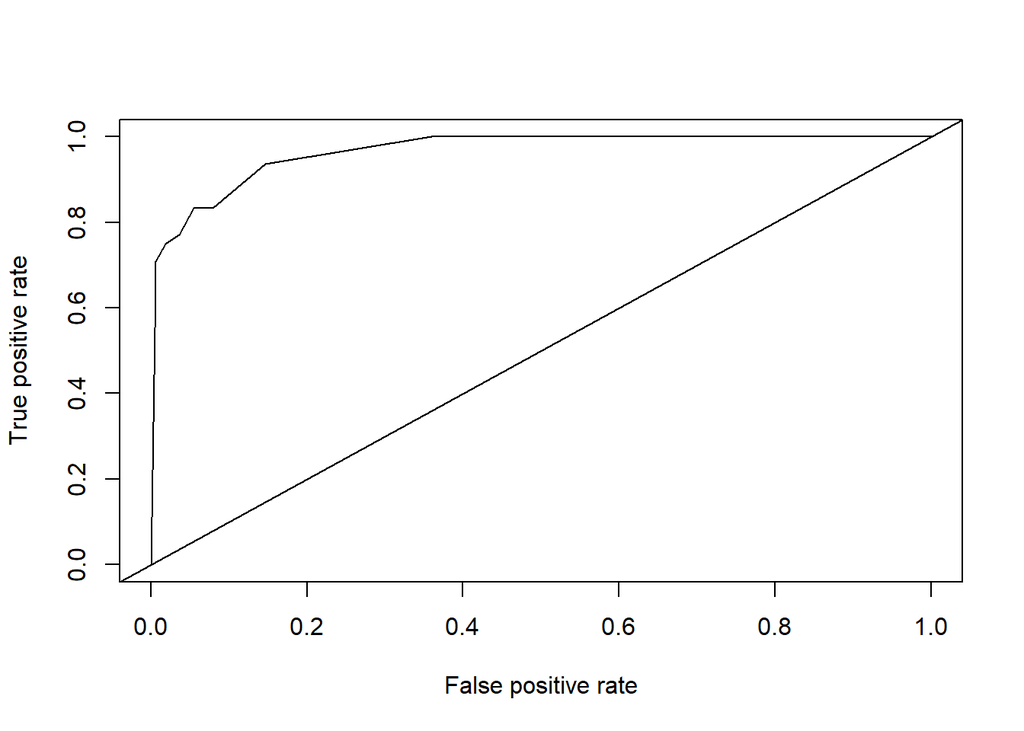

```r
#auc = 0.9662093
plot(performance(out_tree, "tpr", "fpr"))
abline(0,1)
```

Here are the accuracy and AUC statistics for our model:

1. The accuracy is 0.9292 which is great. This % shows how often the model is correct. 100% is perfect.
2. The AUC is 0.9662093 very good. Receiver operating characteristic (ROC), defined as a plot of sensitivity (from our confusion matrix) as the y coordinate versus its 1-specificity (from our confusion matrix) aka false positive rate (FPR) as the x coordinate. AUC is area under this. AUC represents measure of separability and tells us how much the model is capable of distinguishing between classes. The higher the AUC, the better the model is at predicting 0s as 0s and 1s as 1s for example. AUC ranges from 0 to 1 with .50 meaning the model has no class separation capacity.

### **Random Forest Model**

```r
set.seed(101)
control_rand_for = trainControl(method="repeatedcv", number=10, repeats=3)
metric = "Accuracy"
n= round(sqrt(ncol(data)))
tunegrid = expand.grid(.mtry=seq(by = 1,to = 5, from = 1))
rand_for = train(Class_ASD ~ ., data=train, method="rf",
                 metric=metric, tuneGrid= tunegrid, trControl=control_rand_for)
#print(rand_for)
#best mtry = 4, accuracy = 0.9600272 and kappa = 0.8988537
pred_rf_caret = predict(rand_for, test_without_y)
pred_rf2 = predict(rand_for, test_without_y, type="prob")[,2]
confusionMatrix(pred_rf_caret, test_with_y)
```

```
## Confusion Matrix and Statistics
##
##           Reference
## Prediction  NO YES
##        NO  163   5
##        YES   1  43
##
##                Accuracy : 0.9717
##                  95% CI : (0.9394, 0.9895)
##     No Information Rate : 0.7736
##     P-Value [Acc > NIR] : <2e-16
##
##                   Kappa : 0.9168
##
##  Mcnemar's Test P-Value : 0.2207
##
##             Sensitivity : 0.9939
##             Specificity : 0.8958
##          Pos Pred Value : 0.9702
##          Neg Pred Value : 0.9773
##              Prevalence : 0.7736
##          Detection Rate : 0.7689
##    Detection Prevalence : 0.7925
##       Balanced Accuracy : 0.9449
##
##        'Positive' Class : NO
##
```

```r
#accuracy = 0.9717
#p-value = <2e-16
#kappa= 0.9168
#sensitivity = 0.9939
#specificity = 0.8958

#auc
out_rf = prediction(pred_rf2, test_with_y)
auc_rf = performance(out_rf, measure = "auc")@y.values[[1]]
auc_rf
```

```
## [1] 0.9991108
```

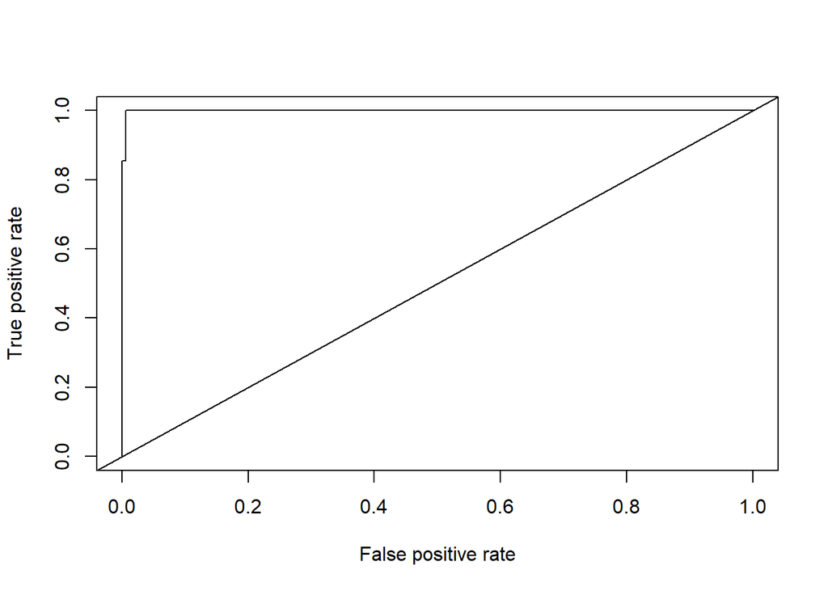

```r
#auc = 0.9991108
plot(performance(out_rf, "tpr", "fpr"))
abline(0,1)
```

```r
#shows important variables in model
important = varImp(rand_for)
important
```

```
## rf variable importance
##
##   only 20 most important variables shown (out of 30)
##
##                           Overall
## A9_Score.1                100.000
## A5_Score.1                 85.846
## A6_Score.1                 78.817
## A4_Score.1                 52.266
## A3_Score.1                 40.317
## A7_Score.1                 36.167
## A1_Score.1                 36.161
## age                        32.493
## A2_Score.1                 31.801
## A10_Score.1                31.102
## A8_Score.1                 23.893
## ethnicity.White.European   21.603
## gender.m                    7.694
## relation.Self               7.232
## autism.yes                  6.042
## ethnicity.Middle.Eastern.   5.412
## jaundice.yes                4.986
## ethnicity.Black             4.559
## ethnicity.Unknown           4.178
## relation.Unknown            3.770
```

```r
#A9_Score.1                100.000
#A5_Score.1                 85.846
#A6_Score.1                 78.817
#A4_Score.1                 52.266
#all social que questions where autistic individuals have challenges. Makes sense these are important!
```

```r
#for loop to determine best number of trees using ntree
accu = rep(0,1000)
for (i in 1:1000) {
  set.seed(i)
  rand_for = randomForest(Class_ASD~ ., data=train, ntree=i)
  pred_loop = predict(rand_for, test_without_y)
  cm = confusionMatrix(pred_loop, test_with_y)

  accu[i] = cm[3]$overall[1]
}
accu
```

```r
max(accu)
```

```
## [1] 0.9858491
```

```r
#max accuracy = 0.9858491
#trees = 32

#using 32 trees and now determining best mtry
control_rand_for32 = trainControl(method="repeatedcv", number=10, repeats=3)
metric = "Accuracy"
n= round(sqrt(ncol(train)))
tunegrid = expand.grid(.mtry=seq(by = 1,to = 5, from = 1))
rand_for32 = train(Class_ASD ~ ., data=train, method="rf", ntree=32,
                   metric=metric, tuneGrid= tunegrid, trControl=control_rand_for32)
#print(rand_for32)
#with 32 trees best mtry = 4
#accuracy = 0.9505578
#kappa = 0.8748667

#best model created and tested
rf_model_best = randomForest(Class_ASD~ ., data=train, ntree=32, mtry=4)
#rf_model_best

pred_rf_best = predict(rf_model_best, test_without_y)
pred_rf3 = predict(rf_model_best, test_without_y, type="prob")[,2]
confusionMatrix(pred_rf_best, test_with_y)
```

```
## Confusion Matrix and Statistics
##
##           Reference
## Prediction  NO YES
##        NO  163   8
##        YES   1  40
##
##                Accuracy : 0.9575
##                  95% CI : (0.9209, 0.9804)
##     No Information Rate : 0.7736
##     P-Value [Acc > NIR] : 8.575e-14
##
##                   Kappa : 0.8722
##
##  Mcnemar's Test P-Value : 0.0455
##
##             Sensitivity : 0.9939
##             Specificity : 0.8333
##          Pos Pred Value : 0.9532
##          Neg Pred Value : 0.9756
##              Prevalence : 0.7736
##          Detection Rate : 0.7689
##    Detection Prevalence : 0.8066
##       Balanced Accuracy : 0.9136
##
##        'Positive' Class : NO
##
```

```r
#accuracy = 0.9575
#p-value = 8.575e-14
#kappa= 0.8722
#sensitivity = 0.9939
#specificity = 0.8333

#auc
out_rf2 = prediction(pred_rf3, test_with_y)
auc_rf2 = performance(out_rf2, measure = "auc")@y.values[[1]]
auc_rf2
```

```
## [1] 0.9912348
```

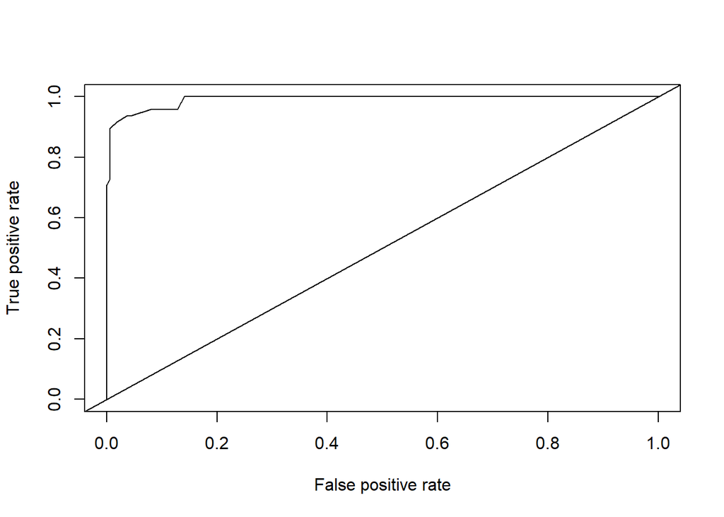

```r
#auc = 0.9912348
plot(performance(out_rf2, "tpr", "fpr"))
abline(0,1)
```

Here are the accuracy and AUC statistics for our model:

1. The accuracy is 0.9575 which is good. This % shows how often the model is correct. 100% is perfect.
2. The AUC is 0.9912348 which is excellent. Receiver operating characteristic (ROC), defined as a plot of sensitivity (from our confusion matrix) as the y coordinate versus its 1-specificity (from our confusion matrix) aka false positive rate (FPR) as the x coordinate. AUC is area under this. AUC represents measure of separability and tells us how much the model is capable of distinguishing between classes. The higher the AUC, the better the model is at predicting 0s as 0s and 1s as 1s for example. AUC ranges from 0 to 1 with .50 meaning the model has no class separation capacity.

### **SVM Model**

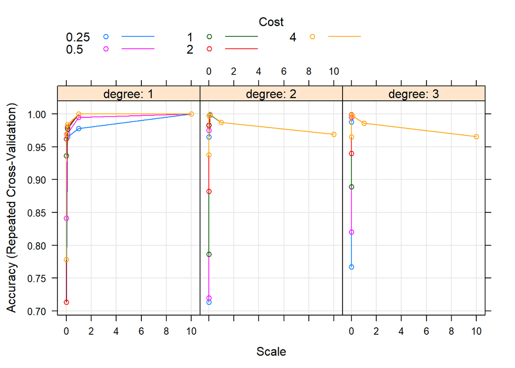

```r
set.seed(101)
y = train$Class_ASD
x = subset(train, select =-Class_ASD)

poly_mod = train(x, y, method="svmPoly", allowParallel = FALSE, scale=FALSE, tuneLength=5,
                 trControl=trainControl(method="repeatedcv",
                                        number=10, repeats=3))
#to see performance
#poly_mod
#final values used for the model were degree = 1, scale = 10 (1e+01) and C = 0.25.
#accuracy =  1.0000000 and kappa = 1.00000000
plot(poly_mod)
```

```r
#degree = 1, scale = 10 (1e+01) and C = 0.25

linea_mod = train(x, y, method="svmLinear", scale=FALSE, tuneLength=5,
                  trControl=trainControl(method="repeatedcv",
                                         number=10, repeats=3))
linea_mod
```

```
## Support Vector Machines with Linear Kernel
##
## 492 samples
##  30 predictor
##   2 classes: 'NO', 'YES'
##
## No pre-processing
## Resampling: Cross-Validated (10 fold, repeated 3 times)
## Summary of sample sizes: 443, 443, 443, 443, 443, 442, ...
## Resampling results:
##
##   Accuracy  Kappa
##   1         1
##
## Tuning parameter 'C' was held constant at a value of 1
```

```r
#accuracy = 1
#kappa = 1
#tuning parameter 'C' was held constant at a value of 1

radial_mod = train(x, y, method="svmRadial", allowParallel = FALSE, scale=FALSE, tuneLength=5,
                   trControl=trainControl(method="repeatedcv",
                                          number=10, repeats=3))
#radial_mod
#final values used for the model were sigma = 0.02785584, 0.02537838 and C = 4, 4.
#accuracy = 0.9519048
#kappa = 0.88258734
#tuning parameter 'sigma' was held constant at a value of 0.02537838

pred_poly = predict(poly_mod, test_without_y)
confusionMatrix(pred_poly, test_with_y)
```

```
## Confusion Matrix and Statistics
##
##           Reference
## Prediction  NO YES
##        NO  164   0
##        YES   0  48
##
##                Accuracy : 1
##                  95% CI : (0.9828, 1)
##     No Information Rate : 0.7736
##     P-Value [Acc > NIR] : < 2.2e-16
##
##                   Kappa : 1
##
##  Mcnemar's Test P-Value : NA
##
##             Sensitivity : 1.0000
##             Specificity : 1.0000
##          Pos Pred Value : 1.0000
##          Neg Pred Value : 1.0000
##              Prevalence : 0.7736
##          Detection Rate : 0.7736
##    Detection Prevalence : 0.7736
##       Balanced Accuracy : 1.0000
##
##        'Positive' Class : NO
##
```

```r
#accuracy = 1
#p-value = < 2.2e-16
#kappa= 1
#sensitivity = 1.0000
#specificity = 1.0000
```

```r
#bootstrap 100 samples and calculate the 95% CI and AUC using poly kernal
n = 100
accuracy = rep(0,n)
auc = rep(0,n)
for (i in 1:n) {
  set.seed(i+100)
  new_index = sample(c(1:length(one_hot$Class_ASD)), length(one_hot$Class_ASD), replace=TRUE)
  new_sample = one_hot[new_index,]
  split = sample.split(new_sample$Class_ASD, SplitRatio = 0.8)
  train = subset(new_sample, split==TRUE)
  test.x = subset(subset(new_sample, split==FALSE), select=-Class_ASD)
  test.y = subset(new_sample, split==FALSE)$Class_ASD

  svm_poly = train(Class_ASD~ ., data=train, method="svmPoly",
                   tuneLength = 1, scale=FALSE,
                   trControl= trainControl(method="repeatedcv",
                                           repeats = 5,
                                           classProbs=TRUE))

  #accuracy
  pred = predict(svm_poly, test.x)
  c = confusionMatrix(pred, test.y)
  accuracy[i] = c[3]$overall[1]

  #auc
  pred = predict(svm_poly, test.x, type="prob")[,2]
  out = prediction(pred, test.y)
  auc[i] = performance(out, measure="auc")@y.values[[1]]
}
```

```r
#95% ci for accuracy
#accuracy
accuracy.mean = mean(accuracy)
accuracy.mean
```

```
## [1] 0.9298916
```

```r
#accuracy mean = 0.9298916
#divide your accuracy standard deviation by the square root of your accuracy size
accuracy.me = qnorm(0.975) * sd(accuracy)/sqrt(length(accuracy))
accuracy.me
```

```
## [1] 0.004357928
```

```r
accuracy.lci = accuracy.mean - accuracy.me #lower end of ci
accuracy.lci
```

```
## [1] 0.9255337
```

```r
accuracy.uci = accuracy.mean + accuracy.me #upper end of ci
accuracy.uci
```

```
## [1] 0.9342495
```

```r
#lower ci = 0.9255337
#upper ci = 0.9342495

#95% ci for auc
auc.mean = mean(auc)
auc.me = qnorm(0.975) * sd(auc)/sqrt(length(auc))
auc.lci = auc.mean - auc.me
auc.uci = auc.mean + auc.me
auc.lci
```

```
## [1] 0.9890107
```

```r
auc.uci
```

```
## [1] 0.9922362
```

```r
#lower auc ci = 0.9890107
#upper auc ci = 0.9922362

#auc
pred4 = predict(svm_poly, test.x, type="prob")[,2]
out4 = prediction(pred4, test.y)
auc4 = performance(out4, measure="auc")@y.values[[1]]
auc4
```

```
## [1] 0.9992204
```

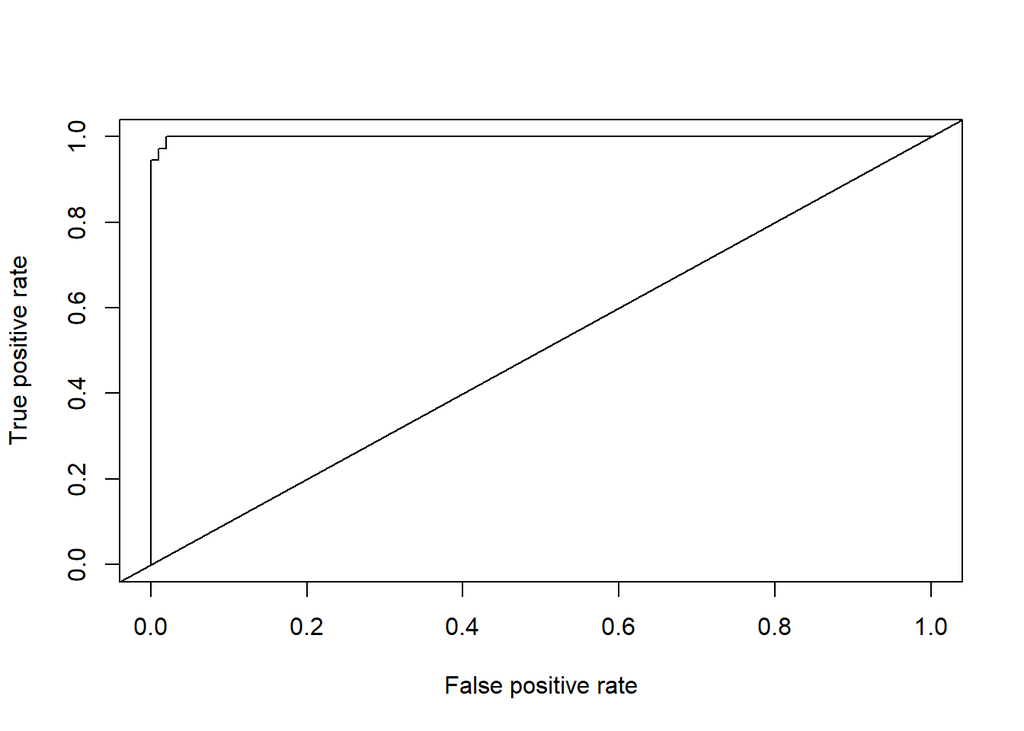

```r
#0.9992204
plot(performance(out4, "tpr", "fpr"))
abline(0,1)
```

Here are the accuracy and AUC statistics for our model:

1. The accuracy is 1 which is perfect. This % shows how often the model is correct. 100% is perfect.
2. The AUC is 0.9992204 which is almost perfect. Receiver operating characteristic (ROC), defined as a plot of sensitivity (from our confusion matrix) as the y coordinate versus its 1-specificity (from our confusion matrix) aka false positive rate (FPR) as the x coordinate. AUC is area under this. AUC represents measure of separability and tells us how much the model is capable of distinguishing between classes. The higher the AUC, the better the model is at predicting 0s as 0s and 1s as 1s for example. AUC ranges from 0 to 1 with .50 meaning the model has no class separation capacity.

### **Model Selection: Lasso**

Lasso coefficient variables can go/shrink to 0. In lasso we remove variables that end up as 0 because they did not explain anything in our model. We will keep variables where the coefficients are not equal to 0 and fit our models with those.

```r
#sets up x with all vars except for target
x = model.matrix(Class_ASD~.,one_hot)[,-31]
#sets up y with target var only
y = one_hot$Class_ASD
train=sample(1:nrow(x), nrow(x)/2)
test=(-train)
y.test=y[test]

cv.out_lasso = cv.glmnet(x[train,],y[train],alpha=1, family="binomial")
#alpha 1 is lasso
#cv.out_lasso
#model output tells you min lambda using mse (mean squared error)
summary(cv.out_lasso)
```

```
##            Length Class  Mode
## lambda     93     -none- numeric
## cvm        93     -none- numeric
## cvsd       93     -none- numeric
## cvup       93     -none- numeric
## cvlo       93     -none- numeric
## nzero      93     -none- numeric
## call        5     -none- call
## name        1     -none- character
## glmnet.fit 13     lognet list
## lambda.min  1     -none- numeric
## lambda.1se  1     -none- numeric
```

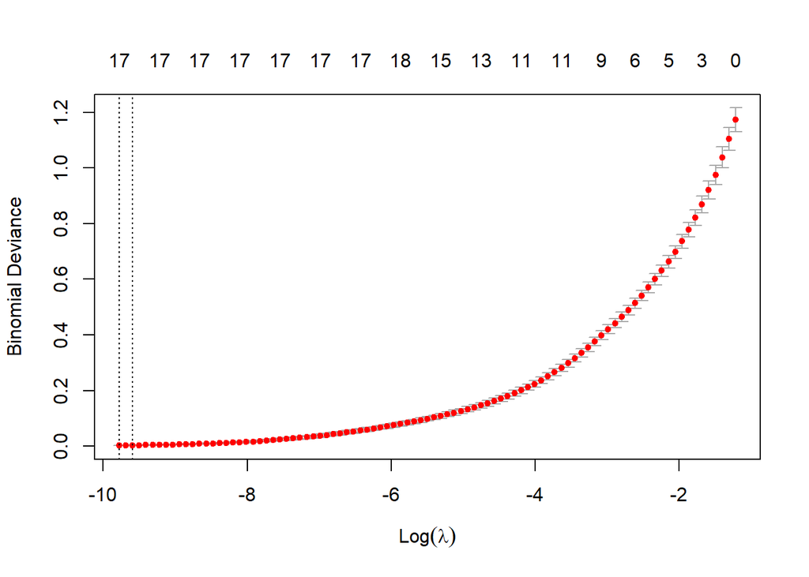

```r
plot(cv.out_lasso)
```

```r
#the best model is under lambda = lambda.min
bestlam = cv.out_lasso$lambda.min
bestlam
```

```
## [1] 5.668239e-05
```

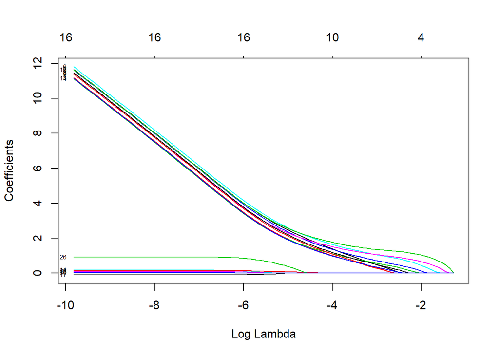

```r
#5.154182e-05 best lambda for lasso
out2 = glmnet(x,y, alpha=1, family = "binomial")
plot(out2, xvar = "lambda", label = TRUE)
```

```r
dim(one_hot)
```

```
## [1] 704  31
```

```r
lasso.coef = predict(out2,type="coefficients",s=bestlam)[1:31,]
lasso.coef
```

```
##               (Intercept)               (Intercept)                A1_Score.1
##              -74.13802060                0.00000000               11.57426702
##                A2_Score.1                A3_Score.1                A4_Score.1
##               11.09409781               11.04119453               11.53794580
##                A5_Score.1                A6_Score.1                A7_Score.1
##               11.72977026               11.30960671               11.37913304
##                A8_Score.1                A9_Score.1               A10_Score.1
##               11.31372557               11.55687037               11.06635789
##                       age                  gender.m           ethnicity.Black
##                0.00000000                0.00000000                0.17495566
##        ethnicity.Hispanic          ethnicity.Latino ethnicity.Middle.Eastern.
##                0.09240012                0.00000000               -0.10880305
##          ethnicity.Others        ethnicity.Pasifika     ethnicity.South.Asian
##                0.00000000                0.00000000                0.00000000
##         ethnicity.Turkish  ethnicity.White.European         ethnicity.Unknown
##                0.00000000                0.12880702                0.00000000
##              jaundice.yes                autism.yes       used_app_before.yes
##                0.00000000                0.00000000                0.91714382
##           relation.Others           relation.Parent         relation.Relative
##                0.00000000                0.00000000                0.00000000
##             relation.Self
##                0.03058752
```

```r
#take out 0 coefficients for lasso, 0 vars did not explain anything in model
lasso.coef[lasso.coef!=0]
```

```
##               (Intercept)                A1_Score.1                A2_Score.1
##              -74.13802060               11.57426702               11.09409781
##                A3_Score.1                A4_Score.1                A5_Score.1
##               11.04119453               11.53794580               11.72977026
##                A6_Score.1                A7_Score.1                A8_Score.1
##               11.30960671               11.37913304               11.31372557
##                A9_Score.1               A10_Score.1           ethnicity.Black
##               11.55687037               11.06635789                0.17495566
##        ethnicity.Hispanic ethnicity.Middle.Eastern.  ethnicity.White.European
##                0.09240012               -0.10880305                0.12880702
##       used_app_before.yes             relation.Self
##                0.91714382                0.03058752
```

```r
#selected variables with coefficients not 0
#A1_Score.1                A2_Score.1
#11.66615201               11.18597353
#A3_Score.1                A4_Score.1                A5_Score.1
#11.13314096               11.62972382               11.82139942
#A6_Score.1                A7_Score.1                A8_Score.1
#11.40151480               11.47105550               11.40556585
#A9_Score.1               A10_Score.1           ethnicity.Black
#11.64865883               11.15825994                0.17539586
#ethnicity.Hispanic   ethnicity.Middle.Eastern.  ethnicity.White.European
#0.09251261               -0.10892936                0.12901819
#used_app_before.yes       relation.Self
#0.91828610                0.03089008

#create lasso selected variabless dataset
lasso_data = one_hot[, c(1:10, 13:14, 16, 21, 25, 29, 31)]
#now 16 columns
```

The lasso selected variables with coefficients that are not 0: A1_Score - A10_Score, ethnicity.Black, ethnicity.Hispanic, ethnicity.Middle.Eastern, ethnicity.White.European, used_app_before.yes and relation.Self.

### **Logistic Regression Model with Lasso Variables**

```r
#take 70% sample
train_split2 = sample(1:nrow(lasso_data), nrow(lasso_data)*0.7)
train2 = lasso_data[train_split2, ]
test_without_y2 = subset(lasso_data[-train_split2, ], select= -Class_ASD)
test_with_y2 = lasso_data[-train_split2, ]$Class_ASD
set.seed(101)
train_control = trainControl(method = "cv", number = 10)

logist_bayes_mod = train(Class_ASD~., data=train2,
                             method = "bayesglm",
                             prior.df=9,
                             trControl = train_control,
                             family="binomial")

summary(logist_bayes_mod)
```

```
##
## Call:
## NULL
##
## Deviance Residuals:
##      Min        1Q    Median        3Q       Max
## -0.70999  -0.01885  -0.00156   0.00246   0.85190
##
## Coefficients:
##                            Estimate Std. Error z value Pr(>|z|)
## (Intercept)               -24.55281    3.18920  -7.699 1.37e-14 ***
## A1_Score.1                  3.95053    0.97098   4.069 4.73e-05 ***
## A2_Score.1                  3.38003    0.81842   4.130 3.63e-05 ***
## A3_Score.1                  2.99953    0.88669   3.383 0.000717 ***
## A4_Score.1                  3.89179    0.90817   4.285 1.82e-05 ***
## A5_Score.1                  4.51831    1.03602   4.361 1.29e-05 ***
## A6_Score.1                  3.58464    0.84727   4.231 2.33e-05 ***
## A7_Score.1                  3.49515    0.84738   4.125 3.71e-05 ***
## A8_Score.1                  3.60721    0.97628   3.695 0.000220 ***
## A9_Score.1                  3.96381    0.81720   4.850 1.23e-06 ***
## A10_Score.1                 2.91709    0.85232   3.423 0.000620 ***
## ethnicity.Black             0.09546    1.20856   0.079 0.937041
## ethnicity.Hispanic          0.06546    1.40421   0.047 0.962821
## ethnicity.Middle.Eastern.  -0.63689    1.10061  -0.579 0.562808
## ethnicity.White.European    0.14361    0.85529   0.168 0.866660
## used_app_before.yes         1.18641    1.75256   0.677 0.498434
## relation.Self               0.81232    0.91184   0.891 0.373008
## ---
## Signif. codes:  0 '***' 0.001 '**' 0.01 '*' 0.05 '.' 0.1 ' ' 1
##
## (Dispersion parameter for binomial family taken to be 1)
##
##     Null deviance: 576.220  on 491  degrees of freedom
## Residual deviance:  20.001  on 475  degrees of freedom
## AIC: 54.001
##
## Number of Fisher Scoring iterations: 16
```

```r
logist_bayes_mod$results
```

```
##   parameter Accuracy Kappa AccuracySD KappaSD
## 1      none        1     1          0       0
```

```r
pred_log_train =predict(logist_bayes_mod, newdata = test_without_y2, type = "raw")
confusionMatrix(pred_log_train, test_with_y2)
```

```
## Confusion Matrix and Statistics
##
##           Reference
## Prediction  NO YES
##        NO  157   0
##        YES   0  55
##
##                Accuracy : 1
##                  95% CI : (0.9828, 1)
##     No Information Rate : 0.7406
##     P-Value [Acc > NIR] : < 2.2e-16
##
##                   Kappa : 1
##
##  Mcnemar's Test P-Value : NA
##
##             Sensitivity : 1.0000
##             Specificity : 1.0000
##          Pos Pred Value : 1.0000
##          Neg Pred Value : 1.0000
##              Prevalence : 0.7406
##          Detection Rate : 0.7406
##    Detection Prevalence : 0.7406
##       Balanced Accuracy : 1.0000
##
##        'Positive' Class : NO
##
```

```r
#accuracy = 1
#p-value = 2.2e-16
#kappa = 1
#sensitivity = 1.0000
#specificity = 1.0000

###### other way to do bayes using bayesglm( )
library(arm)
bayes_logist = bayesglm(Class_ASD ~., data=lasso_data, prior.df=9, family="binomial", control=glm.control(maxit=1))
summary(bayes_logist)
```

```
##
## Call:
## bayesglm(formula = Class_ASD ~ ., family = "binomial", data = lasso_data,
##     control = glm.control(maxit = 1), prior.df = 9)
##
## Deviance Residuals:
##      Min        1Q    Median        3Q       Max
## -0.62048  -0.00595  -0.00045   0.00060   0.64664
##
## Coefficients:
##                           Estimate Std. Error z value Pr(>|z|)
## (Intercept)               -29.4910     3.2520  -9.068  < 2e-16 ***
## A1_Score.1                  4.5771     0.9189   4.981 6.33e-07 ***
## A2_Score.1                  4.1024     0.7706   5.323 1.02e-07 ***
## A3_Score.1                  4.1462     0.8060   5.144 2.69e-07 ***
## A4_Score.1                  4.6531     0.8326   5.589 2.29e-08 ***
## A5_Score.1                  4.8785     0.8871   5.500 3.81e-08 ***
## A6_Score.1                  4.3479     0.7965   5.458 4.80e-08 ***
## A7_Score.1                  4.4816     0.7730   5.798 6.72e-09 ***
## A8_Score.1                  4.3722     0.8497   5.146 2.66e-07 ***
## A9_Score.1                  4.6521     0.7597   6.123 9.16e-10 ***
## A10_Score.1                 4.1371     0.8065   5.130 2.90e-07 ***
## ethnicity.Black             0.6398     1.1269   0.568    0.570
## ethnicity.Hispanic          0.3680     1.3749   0.268    0.789
## ethnicity.Middle.Eastern.  -0.3638     1.0315  -0.353    0.724
## ethnicity.White.European    0.3476     0.7390   0.470    0.638
## used_app_before.yes         0.9013     1.8271   0.493    0.622
## relation.Self               0.3386     0.8060   0.420    0.674
## ---
## Signif. codes:  0 '***' 0.001 '**' 0.01 '*' 0.05 '.' 0.1 ' ' 1
##
## (Dispersion parameter for binomial family taken to be 1)
##
##     Null deviance: 819.072  on 703  degrees of freedom
## Residual deviance:  23.731  on 687  degrees of freedom
## AIC: 57.731
##
## Number of Fisher Scoring iterations: 17
```

```r
bayes_logist$coef
```

```
##               (Intercept)                A1_Score.1                A2_Score.1
##               -29.4909886                 4.5770870                 4.1024247
##                A3_Score.1                A4_Score.1                A5_Score.1
##                 4.1461971                 4.6531172                 4.8785030
##                A6_Score.1                A7_Score.1                A8_Score.1
##                 4.3479151                 4.4815706                 4.3721814
##                A9_Score.1               A10_Score.1           ethnicity.Black
##                 4.6520904                 4.1370888                 0.6397805
##        ethnicity.Hispanic ethnicity.Middle.Eastern.  ethnicity.White.European
##                 0.3680468                -0.3638292                 0.3476198
##       used_app_before.yes             relation.Self
##                 0.9012952                 0.3385895
```

```r
pred_log =predict(bayes_logist, newdata = test_without_y2, type = "response")
asd_or_not_log = ifelse(pred_log >= 0.5, "YES", "NO")
#1 is positive asd and 0 is no asd
#convert to factor: fac_class3
fac_class_log = factor(asd_or_not_log, levels = levels(test_with_y2["Class_ASD"]))
confusionMatrix(fac_class_log, test_with_y2)
```

```
## Confusion Matrix and Statistics
##
##           Reference
## Prediction  NO YES
##        NO  157   0
##        YES   0  55
##
##                Accuracy : 1
##                  95% CI : (0.9828, 1)
##     No Information Rate : 0.7406
##     P-Value [Acc > NIR] : < 2.2e-16
##
##                   Kappa : 1
##
##  Mcnemar's Test P-Value : NA
##
##             Sensitivity : 1.0000
##             Specificity : 1.0000
##          Pos Pred Value : 1.0000
##          Neg Pred Value : 1.0000
##              Prevalence : 0.7406
##          Detection Rate : 0.7406
##    Detection Prevalence : 0.7406
##       Balanced Accuracy : 1.0000
##
##        'Positive' Class : NO
##
```

```r
#accuracy = 1
#p-value = 2.2e-16
#kappa = 1
#sensitivity = 1.0000
#specificity = 1.0000

#auc
out_log = prediction(pred_log, test_with_y2)
auc_log = performance(out_log, measure = "auc")@y.values[[1]]
auc_log
```

```
## [1] 1
```

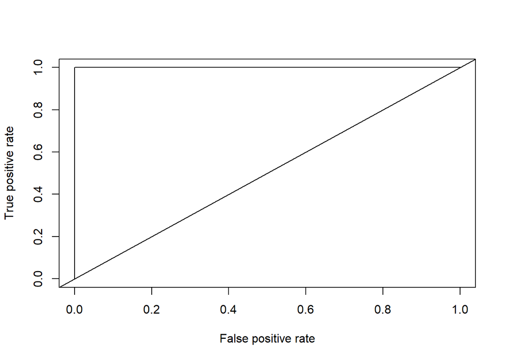

```r
#auc is 0.9992204
plot(performance(out_log, "tpr", "fpr"))
abline(0,1)
```

Our logistic regression model shows the following variables as significant: A1_Score - A10_Score

### **Random Forest Model with Lasso Variables**

```r
set.seed(101)
train_split2 = sample(1:nrow(lasso_data), nrow(lasso_data)*0.7)
train2 = lasso_data[train_split2, ]
test_without_y2 = subset(lasso_data[-train_split2, ], select= -Class_ASD)
test_with_y2 = lasso_data[-train_split2, ]$Class_ASD
control_rand_for = trainControl(method="repeatedcv", number=10, repeats=3)
metric = "Accuracy"
n= round(sqrt(ncol(data)))
tunegrid = expand.grid(.mtry=seq(by = 1,to = 5, from = 1))

rand_for_lasso = train(Class_ASD ~ ., data=train2, method="rf",
                 metric=metric, tuneGrid= tunegrid, trControl=control_rand_for)
#print(rand_for_lasso)
#best mtry was 2: accuracy = 0.9681327 and kappa = 0.9191283

pred_rf_lasso = predict(rand_for_lasso, test_without_y2)
pred_rf_lasso2 = predict(rand_for_lasso, test_without_y2, type="prob")[,2]
confusionMatrix(pred_rf_lasso, test_with_y2)
```

```
## Confusion Matrix and Statistics
##
##           Reference
## Prediction  NO YES
##        NO  164   5
##        YES   0  43
##
##                Accuracy : 0.9764
##                  95% CI : (0.9458, 0.9923)
##     No Information Rate : 0.7736
##     P-Value [Acc > NIR] : < 2e-16
##
##                   Kappa : 0.9301
##
##  Mcnemar's Test P-Value : 0.07364
##
##             Sensitivity : 1.0000
##             Specificity : 0.8958
##          Pos Pred Value : 0.9704
##          Neg Pred Value : 1.0000
##              Prevalence : 0.7736
##          Detection Rate : 0.7736
##    Detection Prevalence : 0.7972
##       Balanced Accuracy : 0.9479
##
##        'Positive' Class : NO
##
```

```r
#accuracy = 0.9528
#p-value = 6.494e-14
#kappa= 0.8635
#sensitivity = 0.9877
#specificity = 0.8400

#auc
out_rf_lasso = prediction(pred_rf_lasso2, test_with_y2)
auc_rf = performance(out_rf_lasso, measure = "auc")@y.values[[1]]
auc_rf
```

```
## [1] 0.9996824
```

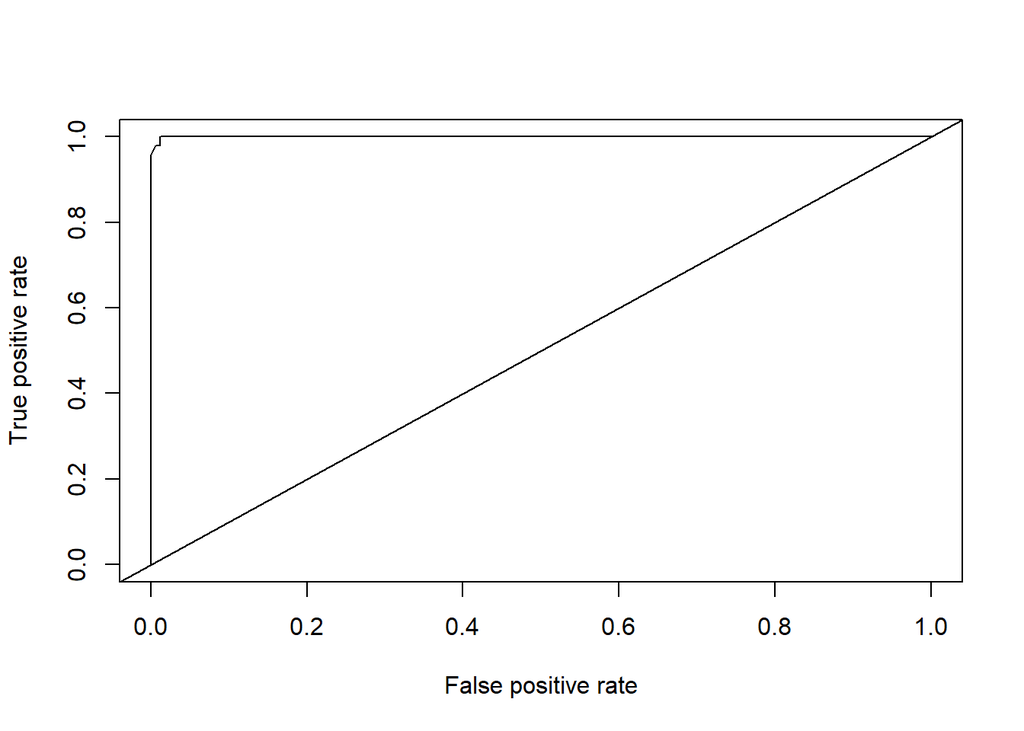

```r
#auc = 0.9960494
plot(performance(out_rf_lasso, "tpr", "fpr"))
abline(0,1)
```

```r
important = varImp(rand_for_lasso)
important
```

```
## rf variable importance
##
##                            Overall
## A9_Score.1                100.0000
## A5_Score.1                 86.4899
## A6_Score.1                 81.2972
## A4_Score.1                 47.5407
## A3_Score.1                 38.6221
## A7_Score.1                 37.0924
## A1_Score.1                 36.1282
## A2_Score.1                 28.9305
## A10_Score.1                27.3222
## A8_Score.1                 22.8606
## ethnicity.White.European   17.0911
## relation.Self               8.3849
## ethnicity.Black             3.3066
## ethnicity.Middle.Eastern.   2.5464
## ethnicity.Hispanic          0.7309
## used_app_before.yes         0.0000
```

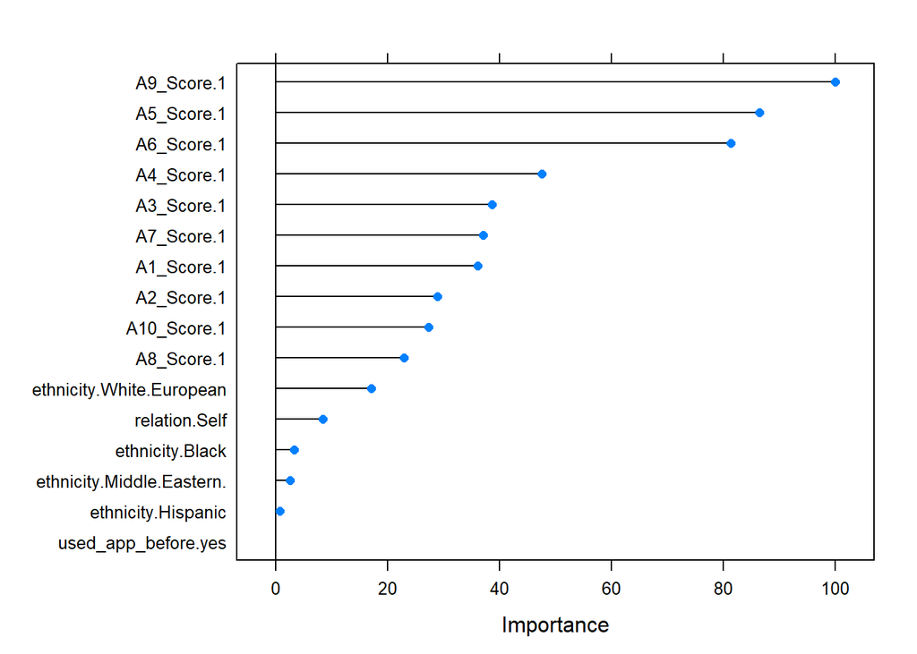

```r
#A9_Score.1                100.000
#A6_Score.1                 80.287
#A5_Score.1                 63.808
#A4_Score.1                 52.380
#all social que questions where autistic individuals have challenges.
#same top 4 as rf using all variables/full model
plot(important)
```

```r
#for loop to determine best number of trees using ntree
accu = rep(0,1000)
for (i in 1:1000) {
  set.seed(i)
  rand_for_lass = randomForest(Class_ASD~ ., data=train2, ntree=i)
  pred_loop = predict(rand_for_lass, test_without_y2)
  cm = confusionMatrix(pred_loop, test_with_y2)

  accu[i] = cm[3]$overall[1]
}
#accu
```

```r
max(accu)
```

```
## [1] 0.995283
```

```r
#max accuracy = 0.9811321
#trees = 17

#using 17 trees and now determining best mtry
control_rand_for17 = trainControl(method="repeatedcv", number=10, repeats=3)
metric = "Accuracy"
n=round(sqrt(ncol(train2)))
tunegrid = expand.grid(.mtry=seq(by = 1,to = 5, from = 1))
rand_for17 = train(Class_ASD ~ ., data=train2, method="rf", ntree=17,
                   metric=metric, tuneGrid= tunegrid, trControl=control_rand_for17)
#print(rand_for17)
#mtry = 3 is best with 17 trees
#accuracy = 0.9682846
#kappa = 0.9203123

#best model created and tested
rf_model_best_lass = randomForest(Class_ASD~ ., data=train2, ntree=17, mtry=3)
#rf_model_best_lass

pred_rf_best_lass = predict(rf_model_best_lass, test_without_y2)
pred_rf_best_lass2 = predict(rf_model_best_lass, test_without_y2, type="prob")[,2]
confusionMatrix(pred_rf_best_lass, test_with_y2)
```

```
## Confusion Matrix and Statistics
##
##           Reference
## Prediction  NO YES
##        NO  162   9
##        YES   2  39
##
##                Accuracy : 0.9481
##                  95% CI : (0.9091, 0.9738)
##     No Information Rate : 0.7736
##     P-Value [Acc > NIR] : 2.854e-12
##
##                   Kappa : 0.8438
##
##  Mcnemar's Test P-Value : 0.07044
##
##             Sensitivity : 0.9878
##             Specificity : 0.8125
##          Pos Pred Value : 0.9474
##          Neg Pred Value : 0.9512
##              Prevalence : 0.7736
##          Detection Rate : 0.7642
##    Detection Prevalence : 0.8066
##       Balanced Accuracy : 0.9002
##
##        'Positive' Class : NO
##
```

```r
#accuracy = 0.9764
#p-value = <2e-16
#kappa= 0.9332
#sensitivity = 0.9938
#specificity = 0.9200

#auc
out_rf17 = prediction(pred_rf_best_lass2, test_with_y2)
auc_rf17 = performance(out_rf17, measure = "auc")@y.values[[1]]
auc_rf17
```

```
## [1] 0.9915523
```

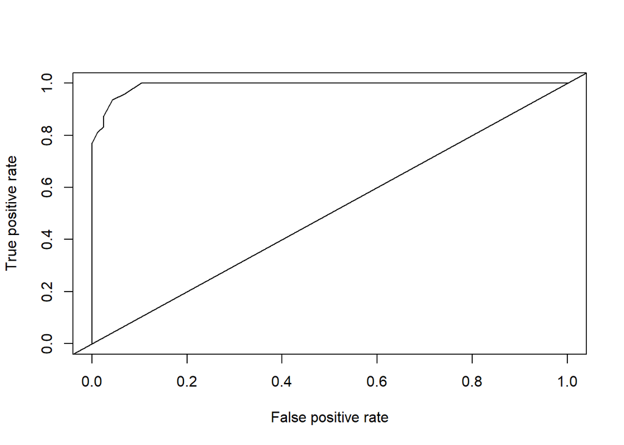

```r
#auc = 0.9961728
plot(performance(out_rf17, "tpr", "fpr"))
abline(0,1)
```

### **Neural Network with Lasso Variables**

```r
#look for best size of hidden layer and decay/learning rate
grid = expand.grid(size=c(2,3,4,5,6,7,8,9,10,11,12,13), decay=c(0, 0.01, 0.1, 1))
```

```r
#model_nn_lasso
model_nn_lasso = train(Class_ASD ~., data=train2, method="nnet", tunegrid=grid, skip=FALSE, linout=FALSE)
#based on accuracy = 0.9948155, the optimal model has a size = 5 and decay = 1e-04
```

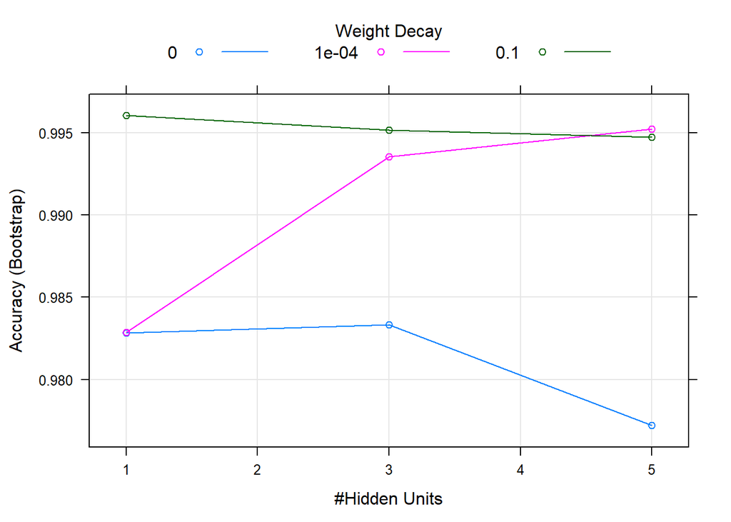

```r
plot(model_nn_lasso)
```

```r
pred_nn = predict(model_nn_lasso, test_without_y2)
pred_nn2 = predict(model_nn_lasso, test_without_y2, type="prob")[,2]
confusionMatrix(pred_nn, test_with_y2)
```

```
## Confusion Matrix and Statistics
##
##           Reference
## Prediction  NO YES
##        NO  164   0
##        YES   0  48
##
##                Accuracy : 1
##                  95% CI : (0.9828, 1)
##     No Information Rate : 0.7736
##     P-Value [Acc > NIR] : < 2.2e-16
##
##                   Kappa : 1
##
##  Mcnemar's Test P-Value : NA
##
##             Sensitivity : 1.0000
##             Specificity : 1.0000
##          Pos Pred Value : 1.0000
##          Neg Pred Value : 1.0000
##              Prevalence : 0.7736
##          Detection Rate : 0.7736
##    Detection Prevalence : 0.7736
##       Balanced Accuracy : 1.0000
##
##        'Positive' Class : NO
##
```

```r
#accuracy = 1
#p-value = 2.2e-16
#kappa = 1
#sensitivity = 1
#specificity = 1


#auc
out_nn = prediction(pred_nn2, test_with_y2)
auc_nn = performance(out_nn, measure = "auc")@y.values[[1]]
auc_nn
```

```
## [1] 1
```

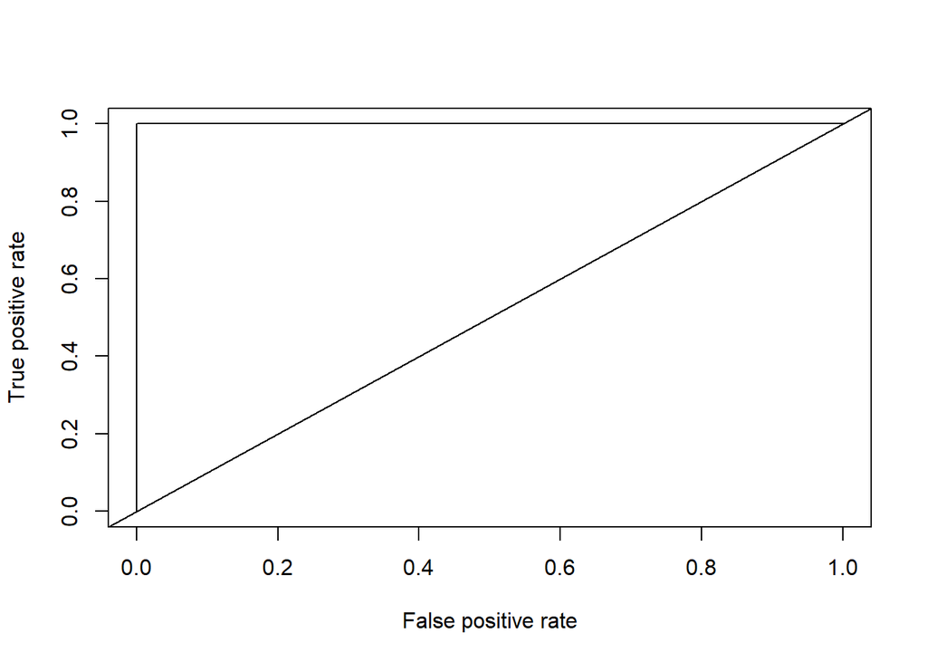

```r
#auc = 1
plot(performance(out_nn, "tpr", "fpr"))
abline(0,1)
```

Here are the accuracy and AUC statistics for our model:

1. The accuracy is 1 which is perfect. This % shows how often the model is correct. 100% is perfect.
2. The AUC is 1 which is perfect. Receiver operating characteristic (ROC), defined as a plot of sensitivity (from our confusion matrix) as the y coordinate versus its 1-specificity (from our confusion matrix) aka false positive rate (FPR) as the x coordinate. AUC is area under this. AUC represents measure of separability and tells us how much the model is capable of distinguishing between classes. The higher the AUC, the better the model is at predicting 0s as 0s and 1s as 1s for example. AUC ranges from 0 to 1 with .50 meaning the model has no class separation capacity.

### **Conclusion**

In evaluation of the predictions of all models, all predicted the target extremely well: before lasso the SVM polynomial kernal model performed best and after lasso the neural network performed best.

I conclude that the survey scores are statistically reliable predictors of the target variable.

100% accuracy is not common but possible. We obtained 100% possibly because of linearly separable data and no overlapping data points? Is there overfitting somehow: memorizing the training set or test and training data are too much alike? The high accuracy scores need to be further researched to determine if the data is truly highly separable or if something else in the data needs to be addressed and the models retrained.

This dataset is highly biased towards the ethnicity of white European. I recommended collecting a more balanced dataset in the future for more accurate and unbiased modeling.

I hypothesize that with further data collection and ML, the survey could indeed be an important aid to clinicians in diagnosing ASD and reducing healthcare costs. ML methods have proven this survey dataset to be useful in predicting the outcomes of the target.